# TreeClassification-HighRes-IndividualUser

Aitor Apaolaza

12/01/2016

*Copyright (c) 2015 The University of Manchester, UK.*

*Licenced under LGPL version 2.1. See LICENCE for details.*

*The IDInteraction Attention Classification was developed in the IDInteraction project, funded by the Engineering and Physical Sciences Research Council, UK through grant agreement number EP/M017133/1.*

*Author: Aitor Apaolaza*

## Initialisation and loading data

```
## [1] "All listed packages are already installed"
```

# Setup for the classification algorithm.

**Folder**: /home/aitor/Dropbox/UoM/IDInteractionCode/Rnotebooks

**Experiment**: dual_screen_free_experiment

**Source Videos**: high_quality

**Tracking system**: front_full_face

**Using the following list of participants**: P01.

**Using the following timelimit threshold to separate training and testing data**: 2.

Data for these participants will be read from the CSV files contained in the following folders:

/home/aitor/Dropbox/UoM/IDInteractionCode/Rnotebooks/resources/dual_screen_free_experiment/high_quality/attention/

/home/aitor/Dropbox/UoM/IDInteractionCode/Rnotebooks/resources/dual_screen_free_experiment/high_quality/front_full_face/

Loading data for participant P01

```
## [1] "Processing participant: P01"
## [1] "START of combineCSVsToDF()"
## [1] "END of combineCSVsToDF()"
## [1] "START of createFeatureDF()"
## [1] "END of createFeatureDF()"
```

From a total of 45858 rows, the first 2 minutes (5535) will be used for training, and the rest for testing (40324).

## Training the tree classifier

Using the **rpart** library for the following formula:

**attentionName ~ boxHeight + boxRotation + boxArea + boxWidth + widthHeightRatio + boxYcoordRel**

Resulting model:

```
## n= 5535
##
## node), split, n, loss, yval, (yprob)
##       * denotes terminal node
##
##   1) root 5535 2095 ipad (0.62149955 0.37850045)
##     2) boxHeight< 32.58165 3224  476 ipad (0.85235732 0.14764268)
##       4) boxYcoordRel>=0.5728612 2433  203 ipad (0.91656391 0.08343609) *
##       5) boxYcoordRel< 0.5728612 791  273 ipad (0.65486726 0.34513274)
##        10) boxRotation>=-7.556265 453  100 ipad (0.77924945 0.22075055) *
##        11) boxRotation< -7.556265 338  165 tv (0.48816568 0.51183432)
##          22) boxYcoordRel< 0.52208 134   28 ipad (0.79104478 0.20895522) *
##          23) boxYcoordRel>=0.52208 204   59 tv (0.28921569 0.71078431)
##            46) boxHeight< 31.69275 23    0 ipad (1.00000000 0.00000000) *
##            47) boxHeight>=31.69275 181   36 tv (0.19889503 0.80110497) *
##     3) boxHeight>=32.58165 2311  692 tv (0.29943747 0.70056253)
##       6) boxHeight< 34.03755 1548  670 tv (0.43281654 0.56718346)
##        12) boxYcoordRel>=0.5918979 264   66 ipad (0.75000000 0.25000000) *
##        13) boxYcoordRel< 0.5918979 1284  472 tv (0.36760125 0.63239875)
##          26) boxYcoordRel< 0.4224706 150   29 ipad (0.80666667 0.19333333) *
##          27) boxYcoordRel>=0.4224706 1134  351 tv (0.30952381 0.69047619)
##            54) boxYcoordRel< 0.5472815 797  311 tv (0.39021330 0.60978670)
##             108) boxRotation< -5.124015 622  287 tv (0.46141479 0.53858521)
##               216) boxRotation>=-7.86817 163   36 ipad (0.77914110 0.22085890) *
##               217) boxRotation< -7.86817 459  160 tv (0.34858388 0.65141612) *
##             109) boxRotation>=-5.124015 175   24 tv (0.13714286 0.86285714) *
##            55) boxYcoordRel>=0.5472815 337   40 tv (0.11869436 0.88130564) *
##       7) boxHeight>=34.03755 763   22 tv (0.02883355 0.97116645) *
```

From the R manual for the Complexity Parameter Table for an Rpart Fit: *The cptable in the fit contains the mean and standard deviation of the errors in the cross-validated prediction against each of the geometric means.*

Matrix of information on the optimal prunings based on a complexity parameter.

```
##
## Classification tree:
## rpart(formula = formula, data = trainsetclass, method = "class")
##
## Variables actually used in tree construction:
## [1] boxHeight    boxRotation  boxYcoordRel
##
## Root node error: 2095/5535 = 0.3785
##
## n= 5535
##
##         CP nsplit rel error  xerror     xstd
## 1 0.442482      0   1.00000 1.00000 0.017224
## 2 0.031504      1   0.55752 0.57279 0.014633
## 3 0.014479      4   0.45060 0.46110 0.013479
## 4 0.013683      7   0.40716 0.44630 0.013306
## 5 0.010979     10   0.36611 0.41766 0.012955
## 6 0.010000     11   0.35513 0.38950 0.012590
```

Visualisation of the Complexity Parameter Table. *A good choice of cp for pruning is often the leftmost value for which the mean lies below the horizontal line.*

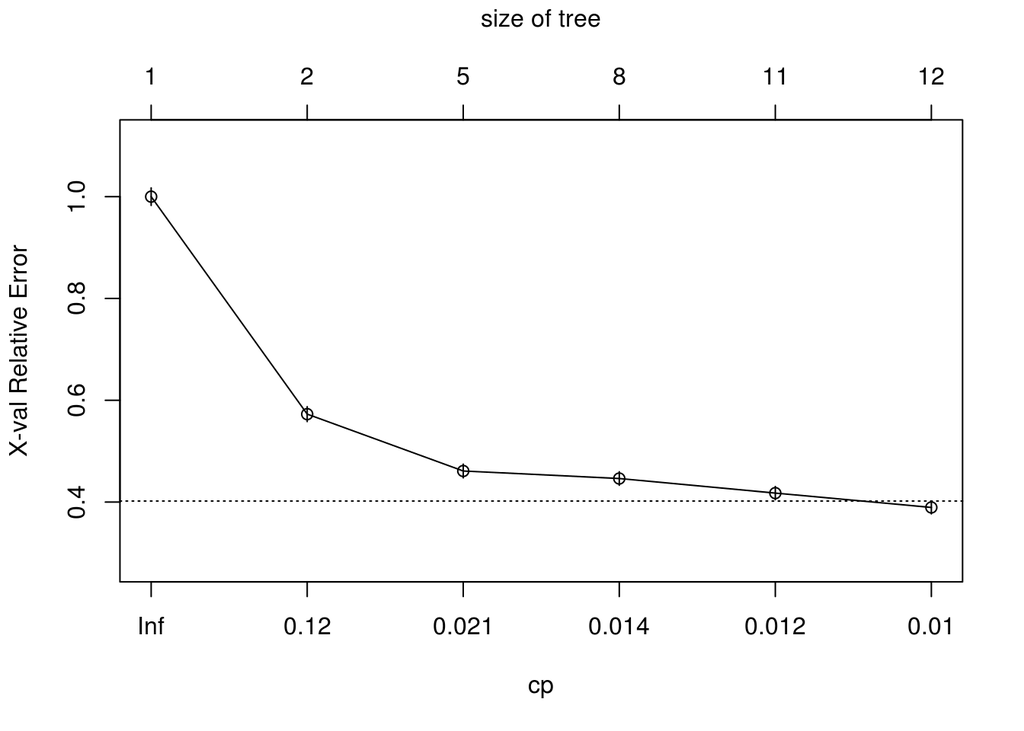

## Tree

### Summary of the tree

```
##
## Model formula:
## attentionName ~ boxHeight + boxRotation + boxArea + boxWidth +
##     widthHeightRatio + boxYcoordRel
##
## Fitted party:
## [1] root
## |   [2] boxHeight < 32.58165
## |   |   [3] boxYcoordRel >= 0.57286: ipad (n = 2433, err = 8.3%)
## |   |   [4] boxYcoordRel < 0.57286
## |   |   |   [5] boxRotation >= -7.55626: ipad (n = 453, err = 22.1%)
## |   |   |   [6] boxRotation < -7.55626
## |   |   |   |   [7] boxYcoordRel < 0.52208: ipad (n = 134, err = 20.9%)
## |   |   |   |   [8] boxYcoordRel >= 0.52208
## |   |   |   |   |   [9] boxHeight < 31.69275: ipad (n = 23, err = 0.0%)
## |   |   |   |   |   [10] boxHeight >= 31.69275: tv (n = 181, err = 19.9%)
## |   [11] boxHeight >= 32.58165
## |   |   [12] boxHeight < 34.03755
## |   |   |   [13] boxYcoordRel >= 0.5919: ipad (n = 264, err = 25.0%)
## |   |   |   [14] boxYcoordRel < 0.5919
## |   |   |   |   [15] boxYcoordRel < 0.42247: ipad (n = 150, err = 19.3%)
## |   |   |   |   [16] boxYcoordRel >= 0.42247
## |   |   |   |   |   [17] boxYcoordRel < 0.54728
## |   |   |   |   |   |   [18] boxRotation < -5.12401
## |   |   |   |   |   |   |   [19] boxRotation >= -7.86817: ipad (n = 163, err = 22.1%)
## |   |   |   |   |   |   |   [20] boxRotation < -7.86817: tv (n = 459, err = 34.9%)
## |   |   |   |   |   |   [21] boxRotation >= -5.12401: tv (n = 175, err = 13.7%)
## |   |   |   |   |   [22] boxYcoordRel >= 0.54728: tv (n = 337, err = 11.9%)
## |   |   [23] boxHeight >= 34.03755: tv (n = 763, err = 2.9%)
##
## Number of inner nodes:    11
## Number of terminal nodes: 12
```

### Visualisation of the tree

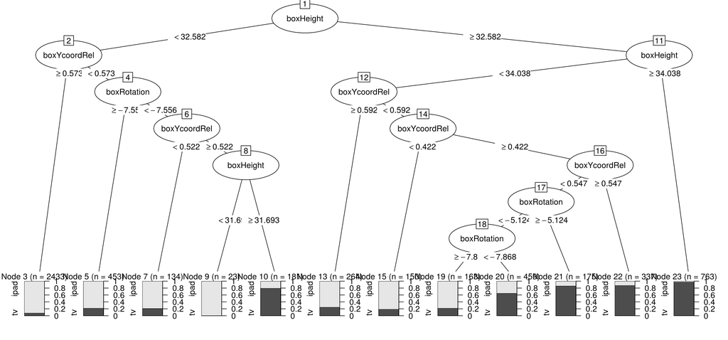

Tree classifier plot

## Error metrics analysis

Confusion matrix from the application of the tree predictor to the testing set of data.

```
##       predclass
##         ipad    tv
##   ipad 14968  1678
##   tv   13509 10169
```

### Error metrics based on prediction of attention to the iPad.

True negatives: 10169

False negatives: 13509

True positives: 14968

False positives: 1678

**Error-rate**: the proportion of the incorrectly classified examples -> (fp+fn)/(tp+tn+fp+tn)

**37.6624343**

**Accuracy**: the proportion of the correctly classified examples -> (tp+tn)/(tp+tn+fp+tn)

**62.3375657**

As the number of instances of the response variable is not balanced (there are many more instances with false than true) the accuracy is not a good indicator. Other cost sensitive measures are reported here. -> cost sensitive measures

**Precision**: positive predicted value (PPV) -> tp/(tp+fp), a measure of exactness

**89.9195002**

**Recall/Sensitivity**: true positive recognition rate -> tp/(tp+fn), a measure of completeness

**52.5617165**

**Specificity**: true negative recognition rate -> tn/(tn+fp)

**85.8360766**

**F measure**: the balance between precision and recall -> 2*tp/(2*tp+fp+fn)

**66.3431066**

# ERROR MEASURES INLINE COPY

**37.6624343** **62.3375657** **89.9195002** **52.5617165** **85.8360766** **66.3431066**

### Error metrics based on prediction of attention to the TV.

True negatives: 14968

False negatives: 1678

True positives: 10169

False positives: 13509

**Error-rate**: the proportion of the incorrectly classified examples -> (fp+fn)/(tp+tn+fp+tn)

**37.6624343**

**Accuracy**: the proportion of the correctly classified examples -> (tp+tn)/(tp+tn+fp+tn)

**62.3375657**

As the number of instances of the response variable is not balanced (there are many more instances with false than true) the accuracy is not a good indicator. Other cost sensitive measures are reported here. -> cost sensitive measures

**Precision**: positive predicted value (PPV) -> tp/(tp+fp), a measure of exactness

**42.9470394**

**Recall/Sensitivity**: true positive recognition rate -> tp/(tp+fn), a measure of completeness

**85.8360766**

**Specificity**: true negative recognition rate -> tn/(tn+fp)

**52.5617165**

**F measure**: the balance between precision and recall -> 2*tp/(2*tp+fp+fn)

**57.2498241**